# TP1 Modèles linéaires

A.V Hurtado Quiceno

1/9/2023

# Part I Regression lineaire simple: donnes appartements:

## Le modèle avec constante $\mathcal{M}_{1}$

Nous allons prédire la variable prix en fonction de surface par un modèle linéaire simple:

$$\left(\mathcal{M}_1\right): \quad prix_i=\beta_0+\beta_1 \text { surface
}_i+\varepsilon_i, \quad i=1, \ldots, 24$$

#### La droite de regression

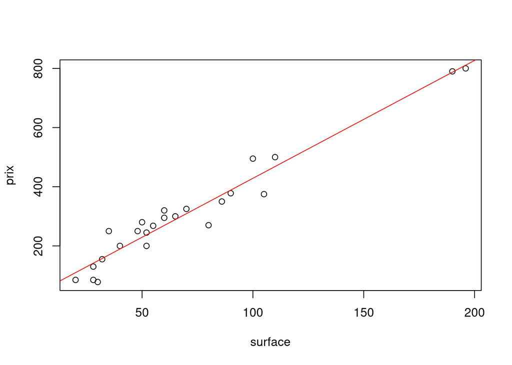

#### Résumé du modèle $\mathcal{M}_1$

```
##
## Call:
## lm(formula = prix ~ surface)
##
## Residuals:
##     Min      1Q  Median      3Q     Max
## -78.845 -23.259   5.293  26.546  80.453
##
## Coefficients:
##             Estimate Std. Error t value Pr(>|t|)
## (Intercept)  30.0921    16.6455   1.808   0.0843 .
## surface       3.9844     0.2003  19.896 1.49e-15 ***
## ---
## Signif. codes:  0 '***' 0.001 '**' 0.01 '*' 0.05 '.' 0.1 ' ' 1
##
## Residual standard error: 43.84 on 22 degrees of freedom
## Multiple R-squared:  0.9474, Adjusted R-squared:  0.945
## F-statistic: 395.9 on 1 and 22 DF,  p-value: 1.485e-15
```

a.)

- Donner les estimations des coefficients pource jeu de données, l’équation de la droite de regression, les valeurs ajustées, les résidus d’estimation.

##### Le coefficients pource jeu de données sont:

$$\hat{\beta}_{0_{\mathcal{M}_{1}}}=30.0921$$

$$\hat{\beta}_{1_{\mathcal{M}_{1}}}= 3.9844$$

```
## (Intercept)     surface
##   30.092132    3.984417
```

$\textbf{Interpretation:}$ Notice that we expected this coefficients since the coefficients for this model are given by the following formula:

$$\hat{\beta_{0}}= \overline{y} - \overline{x}\hat{\beta_{1}}$$
where

$$\hat{\beta_{1}}= \frac{\sum_{i=1}^{n} (x_{i}- \overline{x})(x_{i} -
\overline{y}) }{\sum_{i=1}^{n}(x_{i}- \overline{x})}$$
Therefore;

$$\hat{\beta_{1}}= 3,98\\
\hat{\beta_{0}}= \overline{y} - \overline{x}\hat{\beta_{1}} = 309,33 -
(3,98)(70,083)= 30,09.$$

The values $\overline{y}$ and $\overline{x}$ are as follows:

```
## [1] 309.3333
```

```
## [1] 70.08333
```

- Alors, la droite de régression est :

$$\left(\mathcal{M}_1\right): \quad prix_i=30.0921 + 3.9844 \text {
surface }_i+\varepsilon_i, \quad i=1, \ldots, 24$$

##### Le valeurs ajustées pource jeu de données sont:

```
##        1        2        3        4        5        6        7        8
## 141.6558 229.3130 811.0378 249.2350 787.1313 468.3780 269.1571 221.3441
##        9       10       11       12       13       14       15       16
## 388.6896 169.5467 372.7520 289.0792 157.5935 237.2818 189.4688 309.0013
##       17       18       19       20       21       22       23       24
## 141.6558 149.6246 448.4559 237.2818 348.8455 269.1571 109.7805 428.5338
```

##### Le residuals of the estimation pource jeu de données sont:

```
##          1          2          3          4          5          6          7
## -11.655799  50.687035 -11.037799  18.764951   2.868701  31.622035  50.842868
##          8          9         10         11         12         13         14
##  28.655868 -10.689632  80.453285 -22.751965  10.920785  -2.593465   7.718201
##         15         16         17         18         19         20         21
##  10.531201  15.998701 -56.655799 -71.624632 -73.455882 -37.281799 -78.845465
##         22         23         24
##  25.842868 -24.780465  66.466201
```

- Calculer la moyenne des valeurs ajustées et des résidus d’estimation.

La moyenne des valeurs ajustées est:

$$\bar{\hat{y}}_{\mathcal{M}_{1}}=309.3333.$$

```
## [1] 309.3333
```

La moyenne des résidus d’estimation est:

$$\bar{\hat{\epsilon}}_{\mathcal{M}_{1}}= -9.636389e-16 \approx 0.$$

```
## [1] -9.636389e-16
```

- Que remarquez-vous? Ces résultats etaient-ils prévisibles?

$\textbf{Interpretation:}$

- Dans ce modèle $(\mathcal{M}_{1})$ nous avons cette moyenne des résidus $\hat{\epsilon}_{\mathcal{M}_{1}}$ est 0, et ceci peut être confirmé ici.
- Nous avons $\bar{\hat{y}}_{\mathcal{M}_{1}}=309.3333= \bar{y}_{\mathcal{M}_{1}}$. Ce résultat était également prévisible puisque $\hat{\epsilon}_{\mathcal{M}_{1}}=0$, nous avons que la moyenne des valeurs ajustées, coïncide avec la moyenne de la valeur à prévoir, i.e

$$\frac{1}{n}\sum_{1}^{n} \hat{y}_{i} = \frac{1}{n}\sum_{1}^{n} y_{i}.$$

b.) * Representer graphiquement les residus d’estimation en fonction es valeurs ajustes:

#### Graphique des residues d’estimation en fonction des valeurs ajustées

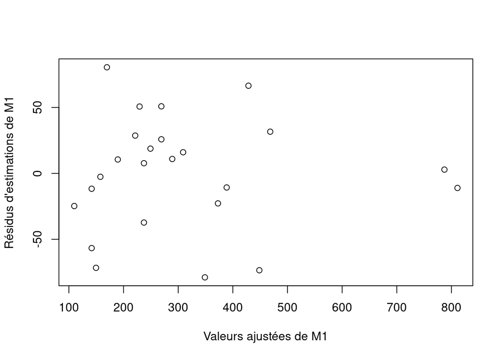

- Est-ce que le modèle considéré semble adapté à ce jeu de données? Combient vaut-il le $R^{2}$?

$\textbf{Interpretation:}$

Dans ce cas puisque notre modèle considère la variable constante 1, nous pouvons interpréter $R^2$. Le modèle semble adapté à ce jeu de données. Nous avons que la valeur $R_{\mathcal{M}_{1}}^2=0.9474$, cela révèle que $94,74%$ de la variabilité observée dans notre variable s’explique par cette régression linéaire simple.

$\textbf{Observation:}$ En général, un R-squared plus élevé indique une plus grande variabilité est expliquée par le modèle.

## Le modèle sans constante $\mathcal{M}_{2}$

On considère maintenant le modèle sans constante:

$$\left(\mathcal{M}_2\right): \quad prix_i=\beta_1 \text { surface
}_i+\varepsilon_i, \quad i=1, \ldots, 24 .$$

#### Résumé du modèle $\mathcal{M}_2$:

```
##
## Call:
## lm(formula = prix ~ surface - 1)
##
## Residuals:
##    Min     1Q Median     3Q    Max
## -75.42 -23.56  19.45  33.46  99.86
##
## Coefficients:
##         Estimate Std. Error t value Pr(>|t|)
## surface   4.2897     0.1129   38.01   <2e-16 ***
## ---
## Signif. codes:  0 '***' 0.001 '**' 0.01 '*' 0.05 '.' 0.1 ' ' 1
##
## Residual standard error: 45.96 on 23 degrees of freedom
## Multiple R-squared:  0.9843, Adjusted R-squared:  0.9836
## F-statistic:  1445 on 1 and 23 DF,  p-value: < 2.2e-16
```

#### Graphique des residues d’estimation en fonction des valeurs ajustées

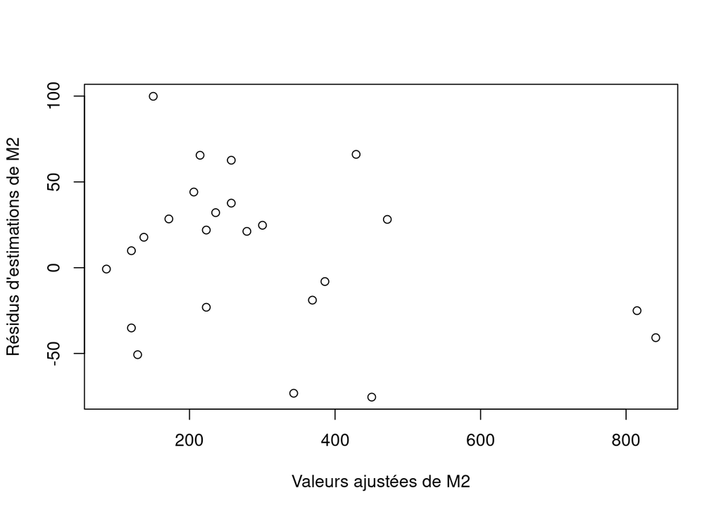

##### The coefficient:

```
##  surface
## 4.289664
```

- Alors, La droite de regression dans le modele $\mathcal{M}_{2})$ est:

$$\left(\mathcal{M}_2\right): \quad prix_i= 4.2897 \,\,
surface_i+\varepsilon_i, \quad i=1, \ldots, 24 .$$

a.)

- Que pouvez-vous dire des estimations des coefficients de regression des modèles $\left(\mathcal{M}_1\right)$ et $\left(\mathcal{M}_2\right)$ ?

Dans le modele $(M_{1})$ (avec constant) et $\mathcal{M}_2$ (sans constant) nous avons obtenu que les coefficients sont:

$$\hat{\beta}_{0_{\mathcal{M}_1}}=30.0921,
\hat{\beta}_{1_{\mathcal{M}_1}}= 3.9844,\\
\hat{\beta}_{1_{\mathcal{M}_2}}= 4.2897.$$

$\textbf{Interpretation:}$

Par conséquent, nous pouvons observer que le coefficient $\hat{\beta}_{1_{\mathcal{M}_2}}$ du modèle $(\mathcal{M}_2)$ augmente par rapport au coefficient $\hat{\beta}_{1_{\mathcal{M}_1}}$, cela signifie que le coefficient du modèle sans avoir à tenir compte de la constante augmente (see Brooks, Econometrics).

- Quel est l’effet d’avoir enlevé la constante du modèle sur les estimations de coefficients de regression?

I cannot say this (BECAREFUL). Le $R_{\mathcal{M}_{2}}^2=0.9843$. Cela montre que le coefficient $\beta_1$ explique $98\%$ du modèle et consistent avec les nuages de points aléatoires, contrary of what happens in the linear regression with a constant, where just $R_{\mathcal{M}_{1}}^2=0.9474$.

b.)

- Calculez la moyenne des valeurs ajustées et la moyenne des résidus d’estimation.

La moyenne des résidus et des valuers ajustéss est:

$$\bar{\hat{\epsilon}}_{\mathcal{M}_{2}}= 8.69935$$

##### La moyenne des residus

```
## [1] 8.69935
```

$$\bar{\hat{y}}_{\mathcal{M}_{2}}= 300.634$$

##### La moyenne de valeurs ajustées

```
## [1] 300.634
```

- Que remarquez-vous et comment expliquez vous ce résultat?

$\textbf{Interpretation:}$ La moyenne ajustées a diminué et la moyenne des résidus d’estimation a augmenté. Dans ce modèle nous ne considérons pas la constante, cela signifie que le vecteur des résidus d’estimation n’est plus orthogonal au vecteur des valeurs ajustees, cela implique que la moyenne des résidus n’est pas nulle comme on peut le voir, (i.e $\bar{\hat{\epsilon}}_{\mathcal{M}_{2}} \neq 0$).

## Le modèle avec constante $\tilde{\mathcal{M}}_ {1}$ (avec la variable surface centre)

On veut prédire maintenant la variable prix en utilisant la variable surface d’abord centrée, ensuite réduite, plus la constante:

$$\left(\tilde{\mathcal{M}}_1\right): \quad
prix_i=\tilde{\beta}_0+\tilde{\beta}_1 surface_i+\varepsilon_i = X
\tilde{\beta} + \epsilon, \quad i=1, \ldots, 24,$$

où surface est la variable centrée de surface.

a.)

- Centrer d’abord la variable surface pour obtenir surface.

#### Data initial avec la variable surface centrée

```
##         surface prix
## 1  -42.08333333  130
## 2  -20.08333333  280
## 3  125.91666667  800
## 4  -15.08333333  268
## 5  119.91666667  790
## 6   39.91666667  500
## 7  -10.08333333  320
## 8  -22.08333333  250
## 9   19.91666667  378
## 10 -35.08333333  250
## 11  15.91666667  350
## 12  -5.08333333  300
## 13 -38.08333333  155
## 14 -18.08333333  245
## 15 -30.08333333  200
## 16  -0.08333333  325
## 17 -42.08333333   85
## 18 -40.08333333   78
## 19  34.91666667  375
## 20 -18.08333333  200
## 21   9.91666667  270
## 22 -10.08333333  295
## 23 -50.08333333   85
## 24  29.91666667  495
```

- Réalisez le modèle $\left(\tilde{\mathcal{M}}_1\right)$

#### La droite de regresion

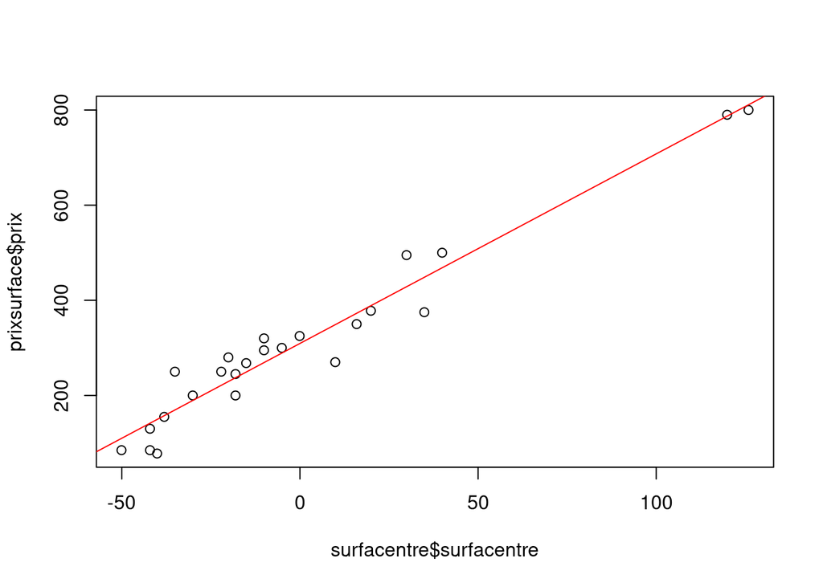

#### Résumé du modèle $\tilde{\mathcal{M}}_ {1}$

```
##
## Call:
## lm(formula = prixsurface$prix ~ surfacentre$surfacentre)
##
## Residuals:
##     Min      1Q  Median      3Q     Max
## -78.845 -23.259   5.293  26.546  80.453
##
## Coefficients:
##                         Estimate Std. Error t value Pr(>|t|)
## (Intercept)             309.3333     8.9498   34.56  < 2e-16 ***
## surfacentre$surfacentre   3.9844     0.2003   19.90 1.49e-15 ***
## ---
## Signif. codes:  0 '***' 0.001 '**' 0.01 '*' 0.05 '.' 0.1 ' ' 1
##
## Residual standard error: 43.84 on 22 degrees of freedom
## Multiple R-squared:  0.9474, Adjusted R-squared:  0.945
## F-statistic: 395.9 on 1 and 22 DF,  p-value: 1.485e-15
```

b.)

- Quelles sont les estimations des coefficients de regression dans le modèle $\left(\tilde{\mathcal{M}}_1\right)$ ?

Les estimaterus obtenu dan cet modeles sont:

$$\hat{\beta}_{0_{\tilde{\mathcal{M}}_1}}=309.3333,
\hat{\beta}_{1_{\tilde{\mathcal{M}}_1}}=3.9844,$$

- Comparez-les avec les estimations obtenues avec le modèle $\left(\mathcal{M}_1\right)$ et commentez le résultat.

Rappelez-vous que les coefficients du modèle $(\mathcal{M}_{1})$ sont:

$$\hat{\beta}_{0_{\mathcal{M}_1}}=30.0921,
\hat{\beta}_{1_{\mathcal{M}_1}}= 3.9844$$

$\textbf{Interpretation:}$ On peut voir que la valeur de la pente dans les deux modèles coïncide $\hat{\beta}_{1_{\mathcal{M}_1}}=\hat{\beta}_{1_{\tilde{\mathcal{M}}_1}}=3.9844$, alors que la valeur du $\beta_{0}$ sont complètement différents. Nous devons remarquer ici que le coefficient d’interception est égal à la moyenne de la valeur ajustée de $y$ dans le modèle $\mathcal{M}_{1}$, i.e

$$\hat{\beta}_{0_{\tilde{\mathcal{M}}_1}}=309.3333 =
\overline{\hat{y}}_{\mathcal{M}_{1}}.$$

- Pourriez-vous donner un résultat théorique qui relie l’expression du vecteur des estimateurs de moindres carrés $\left(\hat{\beta}_0, \hat{\beta}_1\right)^{\top}$ du modèle $\left(\mathcal{M}_1\right)$ aux $\left(\widehat{\tilde{\beta}}_0, \widehat{\tilde{\beta}}_1\right)^{\top}$ du modèle $\left(\tilde{\mathcal{M}}_1\right)$?

$\textbf{Proof:}$ On sait que $\hat{\beta}=(X^{\intercal}X)^{-1}X^{\intercal}y$ par la metode the moindres carres.

$$Y_i=\beta_1+\beta_2 X_i+\varepsilon_i,$$
et nous définissons $\bar{X}$ comme la moyenne du régresseur: $\overline{X}=X_1+ \cdots+ X_n$ et nous pouvons réécrire le modèle comme
$$Y_i=\beta_1+\beta_2
\bar{X}+\beta_2\left(X_i-\bar{X}\right)+\varepsilon_i \\
=\widetilde{\beta}_1+\beta_2 \widetilde{X}_i+\varepsilon_i,$$

où $\widetilde{\beta}_1:=\beta_1+\beta_2 \bar{X}$ et $\widetilde{X}_i:=X_i-\bar{X}$. $\widetilde{X}$ est une variable centrée. Ce faisant, nous avons rendu le modèle orthogonal. Cela simplifie considérablement le calcul, à la fin on peut revenir au paramétrage d’origine. Sous forme de matrice, nous avons et oublier le tilde pour la facilité de notation

$$\left(\begin{array}{c}
Y_1 \\
\vdots \\
Y_n
\end{array}\right)=\left(\begin{array}{cc}
1 & X_1 \\
\vdots & \vdots \\
1 & X_n
\end{array}\right)\left(\begin{array}{c}
\beta_1 \\
\beta_2
\end{array}\right)+\left(\begin{array}{c}
\varepsilon_1 \\
\vdots \\
\varepsilon_n
\end{array}\right) .$$
Soit

$$X=\left(\begin{array}{cc}
1 & X_1 \\
\vdots & \vdots \\
1 & X_n
\end{array}\right)$$
Et, bien sûr,

$$\beta=\left(\begin{array}{l}
\beta_1 \\
\beta_2
\end{array}\right),$$

nous pouvons utiliser

$$X^{\prime} X=\left(\begin{array}{cc}
n & \sum X_i \\
\sum X_i & \sum\left(X_i\right)^2
\end{array}\right)=\left(\begin{array}{cc}
n & 0 \\
0 & \sum\left(X_i\right)^2
\end{array}\right) \text { yielding }\left(X^{\prime}
X\right)^{-1}=\left(\begin{array}{cc}
n^{-1} & 0 \\
0 & \left(\sum\left(X_i \right)^2\right)^{-1}
\end{array}\right)$$

De plus,

$$X^{\prime} Y=\left(\begin{array}{ccc}
1 & \ldots & 1 \\
X_1 & \ldots & X_n
\end{array}\right)\left(\begin{array}{c}
Y_1 \\
\vdots \\
Y_n
\end{array}\right)=\left(\begin{array}{c}
\sum Y_i \\
\sum Y_i X_i
\end{array}\right)$$

par conséquent

$$\widehat{\beta}=\left(\begin{array}{c}
\widehat{\beta_0} \\
\widehat{\beta_1}
\end{array}\right)=\left(\begin{array}{cc}
n^{-1} & 0 \\
0 & \left(\sum\left(X_i\right)^2\right)^{-1}
\end{array}\right)\left(\begin{array}{c}
\sum Y_i \\
\sum Y_i X_i
\end{array}\right)=\left(\begin{array}{c}
n^{-1} \sum Y_i \\
\left(\sum Y_i X_i\right)\left(\sum\left(X_i\right)^2\right)^{-1}
\end{array}\right) .$$

Maintenant nous réintroduisons les tildes avec cette notation que nous avons

$$\begin{aligned}
& \widehat{\widetilde{\beta}}_0=\overline{Y} \\
& \widehat{\beta}_1=\widehat{\widetilde{\beta}}_1=\frac{\sum_{i=1}^n
Y_i\left(X_i-\overline{X}\right)}{\left.\sum_{i=1}^n\left(X_{i} -
\overline{X}
\right.\right)^2}=\frac{\sum_{i=1}^n\left(Y_i-\overline{Y}\right)\left(X_i-\overline{X}\right)}{\sum_{i=1}^n\left(X_i-\overline{X}\right)^2}
\\
& \widehat{\beta}_0=\widehat{\widetilde{\beta}}_0-\widehat{\beta}_1
\overline{X} .
\end{aligned}$$

c.) * Quelles sont les valeurs ajustées avec le modèle $\left(\tilde{\mathcal{M}}_1\right)$ ?

##### Le (fitted values) fitted values

```
##        1        2        3        4        5        6        7        8
## 141.6558 229.3130 811.0378 249.2350 787.1313 468.3780 269.1571 221.3441
##        9       10       11       12       13       14       15       16
## 388.6896 169.5467 372.7520 289.0792 157.5935 237.2818 189.4688 309.0013
##       17       18       19       20       21       22       23       24
## 141.6558 149.6246 448.4559 237.2818 348.8455 269.1571 109.7805 428.5338
```

```
## [1] 309.3333
```

##### Le residuals of the estimation

```
##          1          2          3          4          5          6          7
## -11.655799  50.687035 -11.037799  18.764951   2.868701  31.622035  50.842868
##          8          9         10         11         12         13         14
##  28.655868 -10.689632  80.453285 -22.751965  10.920785  -2.593465   7.718201
##         15         16         17         18         19         20         21
##  10.531201  15.998701 -56.655799 -71.624632 -73.455882 -37.281799 -78.845465
##         22         23         24
##  25.842868 -24.780465  66.466201
```

```
## [1] 3.885781e-15
```

- Comparez-les avec celles obtenues avec le modèle $\left(\mathcal{M}_1\right)$ et commentez le résultat.

La moyenne des résidus d’estimation est:

$$\bar{\hat{\epsilon}}_{\tilde{\mathcal{M}}_1}= 3.885781e-15 \approx 0$$

La moyenne des valuers ajustéss est:

$$\bar{\hat{y}}_{\tilde{\mathcal{M}}_1}= 309.3333$$

- $\textbf{Interpretation:}$ On obtient le meme moyonne des résidus et des valeurs ajustées que dans le modele $\mathcal{M}_{1}$. Puisque dans ce modèle nous considérons la constante, nous avons ici que $\hat{\epsilon}=0$. Par conséquent, nous avons que la moyenne des valeurs ajustées est la même que la moyenne de la variable $y$.

## Le modele sans constante $\tilde{\mathcal{M}}_{2}$

On considère un modèle avec la variable surface centrée et sans constante:

$$(\tilde{\mathcal{M}}_{2}): \operatorname{prix}_i=\tilde{\beta}_{1}
\widetilde{surface}_i+\eta_i, \quad i=1, \ldots, 24,$$

#### Résumé du modèle $\tilde{\mathcal{M}}_{2}$

```
##
## Call:
## lm(formula = prixsurface$prix ~ surfacentre$surfacentre - 1)
##
## Residuals:
##    Min     1Q Median     3Q    Max
##  230.5  286.1  314.6  335.9  389.8
##
## Coefficients:
##                         Estimate Std. Error t value Pr(>|t|)
## surfacentre$surfacentre    3.984      1.456   2.736   0.0118 *
## ---
## Signif. codes:  0 '***' 0.001 '**' 0.01 '*' 0.05 '.' 0.1 ' ' 1
##
## Residual standard error: 318.9 on 23 degrees of freedom
## Multiple R-squared:  0.2455, Adjusted R-squared:  0.2127
## F-statistic: 7.484 on 1 and 23 DF,  p-value: 0.01178
```

#### Graphique des residues d’estimation en fonction des valeurs ajustées

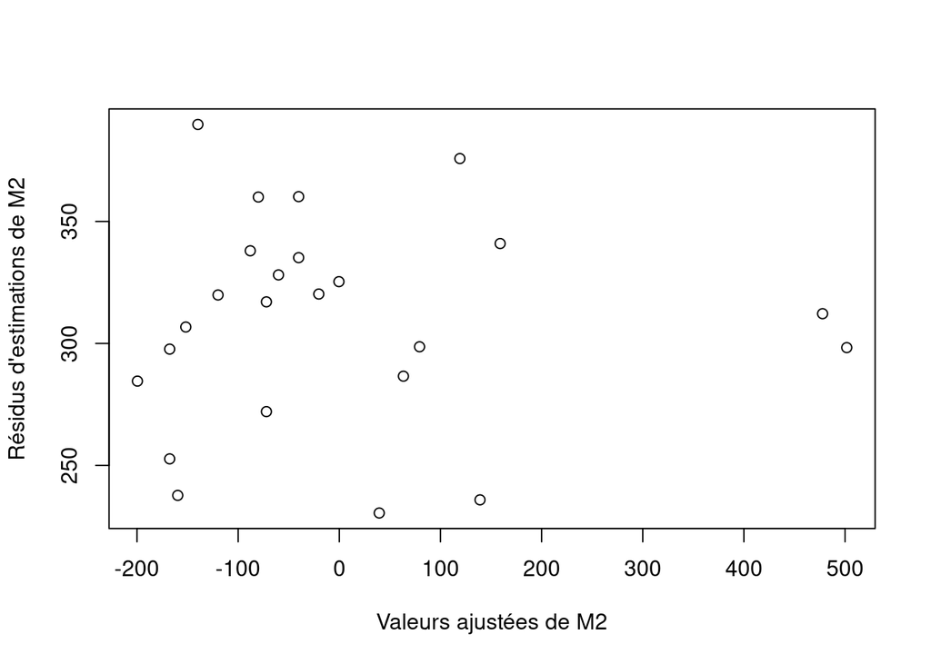

##### The coefficients:

```
## surfacentre$surfacentre
##                3.984417
```

```
## [1] 309.3333
```

```
## [1] 2.4869e-14
```

- Quel est l’estimation de $\tilde{\beta}_1$ dans ce modèle? Comparez-la avec celle obtenue dans le modèle $\left(\tilde{\mathcal{M}}_1\right)$.

$$\hat{\beta}_{1}= 3.9844$$

$\textbf{Interpretation:}$ On peut observer que la valeur de la pente coïncide dans les deux modèles $\hat{\beta}_{1_{\tilde{\mathcal{M}}_1}}= 3.9844= \hat{\beta}_{1}$. Contrairement à ce qui s’est passé dans le modèle $(\mathcal{M}_{1})$ et $(\mathcal{M}_{2})$ où la pente change, ici elle atteint la même chose, même si nous n’avons pas la constante.

## Le modèle avec constant $\tilde{\mathcal{M}}^{*}_{1}$ (avec la variable surface reduite)

- On réduit maintenant la variable surface et on considère le modèle:

$$\left(\mathcal{M}_{1}^{*}\right): \quad
\operatorname{prix}_i=\beta_0^*+\beta_1^* \text { surface
}_i^*+\varepsilon_i, \quad i=1, \ldots, 24,$$

où surface* est la variable réduite.

#### La variable surface reduite

```
##    surfacereduite prix
## 1    -0.921815294  130
## 2    -0.439915813  280
## 3     2.758144374  800
## 4    -0.330393204  268
## 5     2.626717243  790
## 6     0.874355497  500
## 7    -0.220870595  320
## 8    -0.483724857  250
## 9     0.436265060  378
## 10   -0.768483641  250
## 11    0.348646973  350
## 12   -0.111347986  300
## 13   -0.834197207  155
## 14   -0.396106770  245
## 15   -0.658961032  200
## 16   -0.001825377  325
## 17   -0.921815294   85
## 18   -0.878006250   78
## 19    0.764832887  375
## 20   -0.396106770  200
## 21    0.217219842  270
## 22   -0.220870595  295
## 23   -1.097051469   85
## 24    0.655310278  495
```

#### Graphique de la droite de regression

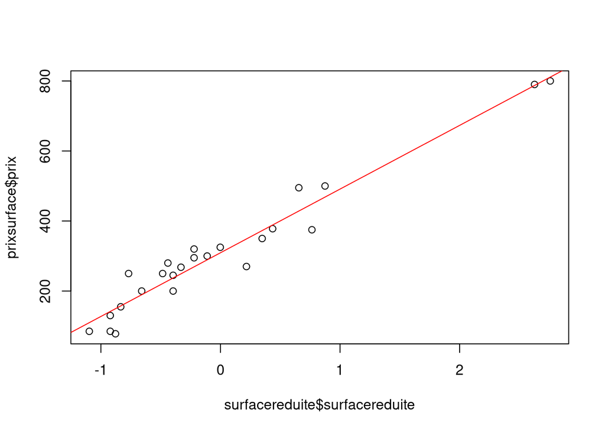

#### Résumé du Modéle $\mathcal{M}_{1}^{*}$

```
##
## Call:
## lm(formula = prixsurface$prix ~ surfacereduite$surfacereduite)
##
## Residuals:
##     Min      1Q  Median      3Q     Max
## -78.845 -23.259   5.293  26.546  80.453
##
## Coefficients:
##                               Estimate Std. Error t value Pr(>|t|)
## (Intercept)                    309.333      8.950   34.56  < 2e-16 ***
## surfacereduite$surfacereduite  181.899      9.142   19.90 1.49e-15 ***
## ---
## Signif. codes:  0 '***' 0.001 '**' 0.01 '*' 0.05 '.' 0.1 ' ' 1
##
## Residual standard error: 43.84 on 22 degrees of freedom
## Multiple R-squared:  0.9474, Adjusted R-squared:  0.945
## F-statistic: 395.9 on 1 and 22 DF,  p-value: 1.485e-15
```

- Répondrez aux mêmes questions ci-dessus:

#### Le coefficients

```
##                   (Intercept) surfacereduite$surfacereduite
##                      309.3333                      181.8993
```

#### Le fitted values

```
##        1        2        3        4        5        6        7        8
## 141.6558 229.3130 811.0378 249.2350 787.1313 468.3780 269.1571 221.3441
##        9       10       11       12       13       14       15       16
## 388.6896 169.5467 372.7520 289.0792 157.5935 237.2818 189.4688 309.0013
##       17       18       19       20       21       22       23       24
## 141.6558 149.6246 448.4559 237.2818 348.8455 269.1571 109.7805 428.5338
```

```
## [1] 309.3333
```

#### Le residuals

```
##          1          2          3          4          5          6          7
## -11.655799  50.687035 -11.037799  18.764951   2.868701  31.622035  50.842868
##          8          9         10         11         12         13         14
##  28.655868 -10.689632  80.453285 -22.751965  10.920785  -2.593465   7.718201
##         15         16         17         18         19         20         21
##  10.531201  15.998701 -56.655799 -71.624632 -73.455882 -37.281799 -78.845465
##         22         23         24
##  25.842868 -24.780465  66.466201
```

```
## [1] 2.975051e-16
```

- On a que les coefficients dans cet modele sont:

$$\widehat{\beta}_{0}^{*}=309.3333$$
$$\widehat{\beta}_{1}^{*}= 181.8993$$

$\textbf{Interpretation}$ On peut observer que

$$\widehat{\beta}_{0}^{*}=309.3333
= \overline{\hat{y}}_{\mathcal{M}_{1}^{*}},$$

- La moyenne de valeurs ajustées et la moyenne de résidus d’estimation sont:

$$\overline{\hat{y}}_{\mathcal{M}_{1}^{*}}= 309.3333$$

$$\overline{\hat{\epsilon}}_{\mathcal{M}_{1}^{*}}=2.975051e-16 \approx 0$$

$\textbf{Interpretation}$ Comme nous nous y attendions puisque ce modèle prend en considération de constant, nous avons que la moyenne des erreurs est zéro. Ensuite, nous avons que $\overline{\hat{y}}_{\mathcal{M}_{1}^{*}}$ coincides with the value of $\overline{\hat{y}}_{\mathcal{M}_{1}}$.

- Pourriez-vous donner un résultat théorique qui relie l’expression du vecteur des estimateurs de moindres carrés $\left(\widehat{\beta}_0^{*}, \widehat{\beta}_{1}^{*}\right)^{\top} \mathrm{du}$ modèle $\left(\mathcal{M}_{1}^{*}\right)$ en fonction des estimateurs de moindres carrés $\left(\widehat{\tilde{\beta}}_0, \widehat{\tilde{\beta}}_1\right)^{\top}$ du modèle $\left(\tilde{\mathcal{M}}_1\right)$ ?

$\textbf{Proof}$

On a que

$$\widehat{\beta}_{0}^{*} = \overline{y}
- \widehat{\beta}_{1}^{*} \overline{x^{*}}= \overline{y} -
\widehat{\beta}_{1}^{*} \frac{1}{\sigma} \overline{x} = \overline{y},$$

alors

$$\begin{aligned}
& \widehat{\beta}_{0}^{*}=\overline{Y} \\
&
\widehat{\beta}_{1}^{*}=\frac{\sum_{i=1}^n\left(Y_{i}-\overline{Y}\right)\left(X_{i}^{*}-\overline{X}^{*}\right)}{\sum_{i=1}^n\left(X_{i}^{*}-\overline{X}^{*}\right)^2}=\frac{\sum_{i=1}^{n}
Y_{i}\left(\frac{X_i}{\sigma}\right)}{\frac{1}{\sigma^{2}}\sum_{i=1}^{n}\left(X_{i}
\right)^2}= \sigma \hat{\tilde{\beta}}_{1} \\
& \widehat{\beta}_{0}^{*}=\overline{y} -\widehat{\beta}_{1}^{*}
\overline{X^{*}}= \overline{y} - \sigma \hat{\tilde{\beta}}_{1}
\frac{1}{\sigma} \overline{\tilde{X}}= \overline{y}
\end{aligned}$$

lorsque l’écart-type de la surface variable est égal à:

```
## [1] 45.65267
```

$$\sigma= 45.65267.$$

Donc on a :

$$\widehat{\beta}_{1}^{*} = (45,652) (3,9844) = 181.8993 = \sigma
\hat{\tilde{\beta}}_{1}, \\
\widehat{\beta}_{0}^{*} = 309.3333 = \widehat{\tilde{\beta} }_{0}.$$

# Part II. Regresion linéaire multiple: données graisse

Considérez les données graisse et on veut prédire le taux de graisse en fonction des autres variables.

## Le modèle multi lineaire avec constante $\mathcal{M}_{1}$ (poids (lb) et taille (pouces))

#### Résumé du modèle $\mathcal{M}_{1}$

```
##
## Call:
## lm(formula = graisse ~ age + poids + taille + adipos + cou +
##     buste + abdom + hanche + cuisse + genou + cheville + biceps +
##     avantb + poignet, data = graissed)
##
## Residuals:
##      Min       1Q   Median       3Q      Max
## -10.0433  -2.5932  -0.1193   2.8698   9.3164
##
## Coefficients:
##              Estimate Std. Error t value Pr(>|t|)
## (Intercept) -49.74275   36.55914  -1.361  0.17493
## age           0.05871    0.03007   1.952  0.05208 .
## poids        -0.17327    0.10060  -1.722  0.08629 .
## taille        0.47077    0.50821   0.926  0.35523
## adipos        0.77667    0.73440   1.058  0.29134
## cou          -0.42834    0.21892  -1.957  0.05157 .
## buste        -0.04253    0.09840  -0.432  0.66600
## abdom         0.87034    0.08583  10.141  < 2e-16 ***
## hanche       -0.22151    0.13816  -1.603  0.11020
## cuisse        0.23855    0.13594   1.755  0.08059 .
## genou        -0.01276    0.23003  -0.055  0.95581
## cheville      0.13557    0.20854   0.650  0.51625
## biceps        0.15170    0.16002   0.948  0.34410
## avantb        0.40486    0.18631   2.173  0.03077 *
## poignet      -1.48070    0.49656  -2.982  0.00316 **
## ---
## Signif. codes:  0 '***' 0.001 '**' 0.01 '*' 0.05 '.' 0.1 ' ' 1
##
## Residual standard error: 3.995 on 236 degrees of freedom
## Multiple R-squared:  0.7475, Adjusted R-squared:  0.7325
## F-statistic: 49.89 on 14 and 236 DF,  p-value: < 2.2e-16
```

#### Coefficient for this model:

```
##  (Intercept)          age        poids       taille       adipos          cou
## -49.74274705   0.05870989  -0.17327448   0.47076812   0.77666844  -0.42834044
##        buste        abdom       hanche       cuisse        genou     cheville
##  -0.04252633   0.87033774  -0.22151147   0.23855250  -0.01275997   0.13557167
##       biceps       avantb      poignet
##   0.15169876   0.40486290  -1.48069897
```

#### Residuals for this model:

```
## [1] -2.322283e-16
```

#### The mean of the fitted values.

```
## [1] 18.88765
```

- Posez le modèle et donnez les estimations des coefficients de régression, le $R_{2}$ , représentez les résidus.

On a le modele suivante:

$$(\mathcal{M}_{1}): \quad graisse_{i} = \beta_{0} +\beta_{1} \,\, age_{i}
+ \beta_{2} \,\, poids_{i} + \beta_{3} \,\, taille_{i} + \sum_{i=4}^{14}
\beta_{i} \,\, x_{i} + \epsilon_{i}.$$

- Après avoir fait la régression multi-linéaire nous avons cela:

$$\hat{\epsilon}_{\mathcal{M}_{1}} = -2.322283e-16 \approx 0.$$

cette valeur est attendue, puisque dans ce modèle nous considérons la constante.

- La moyenne des valeurs ajustées est donnée par:

$$\overline{\hat{y}}_{\mathcal{M}_{1}}= 18.88765$$

- La valeur R-squared est:

$$R^{2}_{\mathcal{M}_{1}}=0.7475.$$

Certains des coefficients les plus importants que je vais mentionner nous permettront de comparer avec les modèles suivants, puisque dans le modèle suivant, la taille et le poids variables changeront l’échelle, alors que l’âge variable ne changera pas:

$$\hat{\beta}_{0_{\mathcal{M}_{1}}}= -49.74275 \\
\hat{\beta}_{1_{\mathcal{M}_{1}}}= 0.05871 \\
\hat{\beta}_{2_{\mathcal{M}_{1}}}= -0.17327 \\
\hat{\beta}_{3_{\mathcal{M}_{1}}}= 0.47077$$

## Le modèle avec constante $\mathcal{M}_{2}$ ( poids(kg) et taille(cm))

- On souhaite transformer la variable poids (en livres) en kg et la taille (en pouces) en cm. Réalisez ces changements et posez le modèle avec ces nouvelles variables.

#### Résumé du modèle $\mathcal{M}_{2}$

```
##
## Call:
## lm(formula = graisse ~ age + poids + taille + adipos + cou +
##     buste + abdom + hanche + cuisse + genou + cheville + biceps +
##     avantb + poignet, data = graissechange2)
##
## Residuals:
##      Min       1Q   Median       3Q      Max
## -10.0433  -2.5932  -0.1193   2.8698   9.3164
##
## Coefficients:
##              Estimate Std. Error t value Pr(>|t|)
## (Intercept) -49.74275   36.55914  -1.361  0.17493
## age           0.05871    0.03007   1.952  0.05208 .
## poids        -0.38166    0.22158  -1.722  0.08629 .
## taille        0.18534    0.20008   0.926  0.35523
## adipos        0.77667    0.73440   1.058  0.29134
## cou          -0.42834    0.21892  -1.957  0.05157 .
## buste        -0.04253    0.09840  -0.432  0.66600
## abdom         0.87034    0.08583  10.141  < 2e-16 ***
## hanche       -0.22151    0.13816  -1.603  0.11020
## cuisse        0.23855    0.13594   1.755  0.08059 .
## genou        -0.01276    0.23003  -0.055  0.95581
## cheville      0.13557    0.20854   0.650  0.51625
## biceps        0.15170    0.16002   0.948  0.34410
## avantb        0.40486    0.18631   2.173  0.03077 *
## poignet      -1.48070    0.49656  -2.982  0.00316 **
## ---
## Signif. codes:  0 '***' 0.001 '**' 0.01 '*' 0.05 '.' 0.1 ' ' 1
##
## Residual standard error: 3.995 on 236 degrees of freedom
## Multiple R-squared:  0.7475, Adjusted R-squared:  0.7325
## F-statistic: 49.89 on 14 and 236 DF,  p-value: < 2.2e-16
```

Comment changent-elles les estimations des coefficients de régression? Et les valeurs ajustées?

$$\hat{\beta}_{0_{\mathcal{M}_{2}}}= -49.74275 \\
\hat{\beta}_{1_{\mathcal{M}_{2}}}= 0.05871 \\
\hat{\beta}_{2_{\mathcal{M}_{2}}}= -0.38166 \\
\hat{\beta}_{3_{\mathcal{M}_{2}}}= 0.18534$$

et les autres valeurs restent les mêmes. Noter que:

$$\hat{\beta}_{2_{\mathcal{M}_{2}}}= -0.38166 =
\frac{1}{0.454} \hat{\beta}_{2_{\mathcal{M}_{1}}}$$
$$\hat{\beta}_{3_{\mathcal{M}_{2}}}= 0.18534 =
\frac{1}{2.54}\hat{\beta}_{3_{\mathcal{M}_{1}}}$$

L’échelle est la suivante:

$$\tilde{X}=X \cdot \operatorname{diag}\left(c_1, c_2, \ldots, c_n\right)$$
OU $c_i$ facteur d’échelle de chaque variable (colonne) et $\tilde{X}$ une version à l’échelle de $X$. Appelons la matrice d’échelle diagonale $C \equiv \operatorname{diag}\left(c_1, c_2, \ldots, c_n\right)$. L’estimateur est donné par :

$$\hat{\beta}=\left(X^T X\right)^{-1} X^T Y$$

Branchez la matrice mise à l’échelle $\tilde{X}$ au lieu de $X$ et utilisez une certaine algèbre de matrice:

$$\begin{aligned}
\hat{\beta}_{\tilde{X}}=& \left(\tilde{X}^T \tilde{X}\right)^{-1}
\tilde{X}^T Y=\left(C^T X^T X C\right)^{-1} C^T X^T Y=C^{-1}\left(X^T
X\right)^{-1} C^{-1} C X^T Y \\
& =C^{-1}\left(X^T X\right)^{-1} X^T Y=C^{-1} \hat{\beta}_{X}
\end{aligned}$$

Ainsi, vous voyez comment le nouveau coefficient est simplement l’ancien coefficient réduit, comme prévu.

### Importance of the R-squared term

Soit le modele

$$graisse_{i} = \beta_{0} + \beta_{1} \,\, poids_{i} + \beta_{2} \,\,
taille_{i}$$

```
##
## Call:
## lm(formula = graisse ~ poids + taille, data = graissed)
##
## Residuals:
##      Min       1Q   Median       3Q      Max
## -22.2869  -3.3755   0.0152   4.1267  12.1992
##
## Coefficients:
##             Estimate Std. Error t value Pr(>|t|)
## (Intercept) 68.23679    9.65018   7.071 1.56e-11 ***
## poids        0.21494    0.01339  16.056  < 2e-16 ***
## taille      -1.24854    0.15055  -8.293 7.06e-15 ***
## ---
## Signif. codes:  0 '***' 0.001 '**' 0.01 '*' 0.05 '.' 0.1 ' ' 1
##
## Residual standard error: 5.429 on 248 degrees of freedom
## Multiple R-squared:  0.5099, Adjusted R-squared:  0.506
## F-statistic:   129 on 2 and 248 DF,  p-value: < 2.2e-16
```

$\textbf{Interpretation:}$

## Le modèle avec constante $\mathcal{M}_{2}$ centre

Réalisez aussi une régression sur les variables explicatives centrées. Pour centrer les variables explicatives, utilisez la fonction sweep décrite en fin de section.

#### Data initial avec la variable poids et taille centre:

```
##
## Call:
## lm(formula = graisse ~ age + poids + taille + adipos + cou +
##     buste + abdom + hanche + cuisse + genou + cheville + biceps +
##     avantb + poignet, data = graissecentre)
##
## Residuals:
##      Min       1Q   Median       3Q      Max
## -13.8410  -3.9795   0.0982   3.8461  16.3934
##
## Coefficients:
##             Estimate Std. Error t value Pr(>|t|)
## (Intercept)  3.34563    1.37687   2.430   0.0159 *
## age          0.08825    0.01130   7.808 1.89e-13 ***
## poids        0.07190    0.01020   7.048 1.98e-11 ***
## taille       0.06886    0.01227   5.613 5.57e-08 ***
## adipos       0.09560    0.01139   8.395 4.35e-15 ***
## cou          0.08795    0.01174   7.490 1.37e-12 ***
## buste        0.08280    0.01165   7.109 1.38e-11 ***
## abdom        0.07771    0.01093   7.113 1.35e-11 ***
## hanche       0.07436    0.01113   6.680 1.70e-10 ***
## cuisse       0.08968    0.01215   7.378 2.72e-12 ***
## genou        0.08208    0.01140   7.201 7.96e-12 ***
## cheville     0.08771    0.01277   6.870 5.64e-11 ***
## biceps       0.07074    0.01150   6.151 3.27e-09 ***
## avantb       0.09942    0.01194   8.326 6.83e-15 ***
## poignet      1.06662    0.01122  95.089  < 2e-16 ***
## ---
## Signif. codes:  0 '***' 0.001 '**' 0.01 '*' 0.05 '.' 0.1 ' ' 1
##
## Residual standard error: 5.758 on 236 degrees of freedom
## Multiple R-squared:  0.9839, Adjusted R-squared:  0.983
## F-statistic:  1032 on 14 and 236 DF,  p-value: < 2.2e-16
```

#### La moyenne de fitted values

```
## [1] -42.81597
```

$$\overline{\hat{y}}= -42.81597$$

#### La moyenne de residues

```
## [1] -3.220124e-17
```

$$\overline{\hat{\epsilon}}= -3.220124e-17 \approx 0$$

## Le modèle avec constante $\mathcal{M}_{2}$ centre et reduite

- Enfin, réalisez une régression sur les variables explicatives centrées et réduite (pour la réduction, utilisez aussi sweep).

```
##
## Call:
## lm(formula = graisse ~ age + poids + taille + adipos + cou +
##     buste + abdom + hanche + cuisse + genou + cheville + biceps +
##     avantb + poignet, data = graissecentre)
##
## Residuals:
##      Min       1Q   Median       3Q      Max
## -11.6728  -1.0300   0.0572   0.9939  12.6544
##
## Coefficients:
##               Estimate Std. Error t value Pr(>|t|)
## (Intercept) -18.638256   2.422881  -7.693 3.90e-13 ***
## age           0.070019   0.017602   3.978 9.25e-05 ***
## poids         0.045915   0.010761   4.267 2.87e-05 ***
## taille        0.021294   0.005083   4.190 3.95e-05 ***
## adipos        0.202361   0.035580   5.687 3.80e-08 ***
## cou           0.114924   0.024020   4.785 3.02e-06 ***
## buste         0.039385   0.008738   4.507 1.03e-05 ***
## abdom         0.041294   0.009814   4.208 3.67e-05 ***
## hanche        0.039173   0.008800   4.451 1.32e-05 ***
## cuisse        0.079677   0.015812   5.039 9.31e-07 ***
## genou         0.101703   0.024201   4.202 3.75e-05 ***
## cheville      0.206620   0.039540   5.226 3.82e-07 ***
## biceps        0.138842   0.029520   4.703 4.36e-06 ***
## avantb        0.134119   0.031621   4.241 3.19e-05 ***
## poignet       1.347749   0.049396  27.284  < 2e-16 ***
## ---
## Signif. codes:  0 '***' 0.001 '**' 0.01 '*' 0.05 '.' 0.1 ' ' 1
##
## Residual standard error: 2.712 on 236 degrees of freedom
## Multiple R-squared:  0.8203, Adjusted R-squared:  0.8097
## F-statistic: 76.96 on 14 and 236 DF,  p-value: < 2.2e-16
```

$$\hat{\beta}_{0}= -18.638256 \\
\hat{\beta}_{1}= 0.070019 \\
\hat{\beta}_{2}= 0.045915 \\
\hat{\beta}_{3}= 0.021294$$

#### La moyenne de fitted values

```
## [1] -42.81597
```

$$\overline{\hat{y}}= -42.81597$$

#### La moyenne de residues

```
## [1] -3.220124e-17
```

$$\overline{\hat{\epsilon}}= -3.220124e-17 \approx 0 .$$

# Part III. Programmes faits à la main

Créer une fonction qui a comme paramètres d’entrée la variable à prédire y et la matrice des variables explicatives $\mathrm{X}$ et en sorties, le vecteur $\hat{\boldsymbol{\beta}}$ des estimateurs de coefficients de régression $\beta$, le vecteur des valeurs ajustées $\hat{\mathbf{y}}$, le vecteur des résidus $\hat{\varepsilon}$ et le $R^2$. Attention, les opérations avec des matrices peuvent prendre rapidement beaucoup de temps, essayez de créer une fonction rapide; vous pouvez utiliser la fonction crossprod pour calculer des produits de matrices avec des transposées et solve(A,b) pour calculer $A^{-1} b$. Comparez vos résultats avec ceux obtenus avec la fonction Im sur les deux jeux de données.

```
## [1] "The intersection value and the slope values are: "
##            [,1]
## Intercept 30.09
## Slope      3.98
## [1] "The mean of the fitted values is:"
## [1] 309.0217
## [1] "The mean of the residuals values is:"
## [1] 0.3116667
## [1] "The value of R^2 is :"
```

```
## [1] 0.9473477
```

### Comparaison entre mon programme et lm:

```
##
## Call:
## lm(formula = prix ~ ., data = prixsurface)
##
## Coefficients:
## (Intercept)      surface
##      30.092        3.984
```

```
##             our.results lm.results
## (Intercept)       30.09      30.09
## surface            3.98       3.98
```